# Machine Learning Final

Melissa Miller

February 18, 2018

Using devices such as Jawbone Up, Nike FuelBand, and Fitbit it is now possible to collect a large amount of data about personal activity relatively inexpensively. These type of devices are part of the quantified self movement - a group of enthusiasts who take measurements about themselves regularly to improve their health, to find patterns in their behavior, or because they are tech geeks. One thing that people regularly do is quantify how much of a particular activity they do, but they rarely quantify how well they do it. In this project, your goal will be to use data from accelerometers on the belt, forearm, arm, and dumbell of 6 participants. They were asked to perform barbell lifts correctly and incorrectly in 5 different ways. More information is available from the website here: http://groupware.les.inf.puc-rio.br/har (see the section on the Weight Lifting Exercise Dataset). The goal of your project is to predict the manner in which they did the exercise. This is the “classe” variable in the training set. You may use any of the other variables to predict with. You should create a report describing how you built your model, how you used cross validation, what you think the expected out of sample error is, and why you made the choices you did. You will also use your prediction model to predict 20 different test cases.

The first part of this is to load the data into the program.

```r
train_data <- read.csv("C:/Users/mloun/Documents/pml-training.csv")
test_data <- read.csv("C:/Users/mloun/Documents/pml-testing.csv")
dim(train_data)
```

```
## [1] 19622   160
```

**Cleaning the DAta** The data needs to be cleaned there are non numeric values and there are NA’s through out the data.

```r
na_factor<-apply(train_data,2,function(col)sum(is.na(col))/length(col))*100
na_factor=as.data.frame(na_factor)
na_factor$colname=rownames(na_factor)
rownames(na_factor)=NULL
#plot_na=ggplot(subset(na_factor,na_factor>95), aes(colname, na_factor))+geom_bar(stat="identity")+coord_flip()
#plot_na
subset_na_95=subset(na_factor, na_factor>95)
na_thrash <- !names(train_data) %in% subset_na_95$colname
train_data_trans <- train_data[,na_thrash]
```

```r
still<-c("kurtosis_roll_belt",  "kurtosis_picth_belt",  "kurtosis_yaw_belt",    "skewness_roll_belt",   "skewness_roll_belt.1", "skewness_yaw_belt", "max_yaw_belt", "min_yaw_belt", "amplitude_yaw_belt", "kurtosis_roll_arm", "kurtosis_picth_arm",   "kurtosis_yaw_arm", "skewness_roll_arm",    "skewness_pitch_arm",   "skewness_yaw_arm", "kurtosis_roll_arm",    "kurtosis_picth_arm",   "kurtosis_yaw_arm", "skewness_roll_arm",    "skewness_pitch_arm",   "skewness_yaw_arm", "kurtosis_roll_dumbbell",   "kurtosis_picth_dumbbell",  "kurtosis_yaw_dumbbell",    "skewness_roll_dumbbell",   "skewness_pitch_dumbbell",  "skewness_yaw_dumbbell" , "max_yaw_dumbbell" ,"min_yaw_dumbbell" ,"amplitude_yaw_dumbbell", "max_yaw_forearm", "max_yaw_forearm", "min_yaw_forearm","kurtosis_picth_forearm", "skewness_yaw_forearm","amplitude_yaw_forearm","kurtosis_picth_forearm","kurtosis_yaw_forearm","skewness_roll_forearm","kurtosis_roll_forearm","skewness_pitch_forearm")
still_thrash <- !names(train_data_trans) %in% still
train_data_trans_1 <- train_data_trans[,still_thrash]
train_data_trans_1<- train_data_trans_1[,-c(1:7)]
train_data_trans_1$classe=as.factor(train_data$classe)
```

**Cross Validation and splitting the data** Cross validation allows us to split the large data into different groups in order to run analysis.

```r
set.seed(77777)
library(caret)
training <- createDataPartition(y=train_data_trans_1$classe,
                               p=0.75,list=FALSE)
training_data <- train_data_trans_1[training,]
validation_data <- train_data_trans_1[-training,]
```

**Coorelation** This allows us to look at varaibles and determine if a relationship exists. Specifically the graph looks like there is a positive coorelation between variables.

```r
m <- abs(cor(training_data[,-53]))
diag(m) <-0
which(m>0.8, arr.ind=T)
```

```
##                  row col
## yaw_belt           3   1
## total_accel_belt   4   1
## accel_belt_y       9   1
## accel_belt_z      10   1
## accel_belt_x       8   2
## magnet_belt_x     11   2
## roll_belt          1   3
## roll_belt          1   4
## accel_belt_y       9   4
## accel_belt_z      10   4
## pitch_belt         2   8
## magnet_belt_x     11   8
## roll_belt          1   9
## total_accel_belt   4   9
## accel_belt_z      10   9
## roll_belt          1  10
## total_accel_belt   4  10
## accel_belt_y       9  10
## pitch_belt         2  11
## accel_belt_x       8  11
## gyros_arm_y       19  18
## gyros_arm_x       18  19
## magnet_arm_x      24  21
## accel_arm_x       21  24
## magnet_arm_z      26  25
## magnet_arm_y      25  26
## accel_dumbbell_x  34  28
## accel_dumbbell_z  36  29
## gyros_dumbbell_z  33  31
## gyros_forearm_z   46  31
## gyros_dumbbell_x  31  33
## gyros_forearm_z   46  33
## pitch_dumbbell    28  34
## yaw_dumbbell      29  36
## gyros_forearm_z   46  45
## gyros_dumbbell_x  31  46
## gyros_dumbbell_z  33  46
## gyros_forearm_y   45  46
```

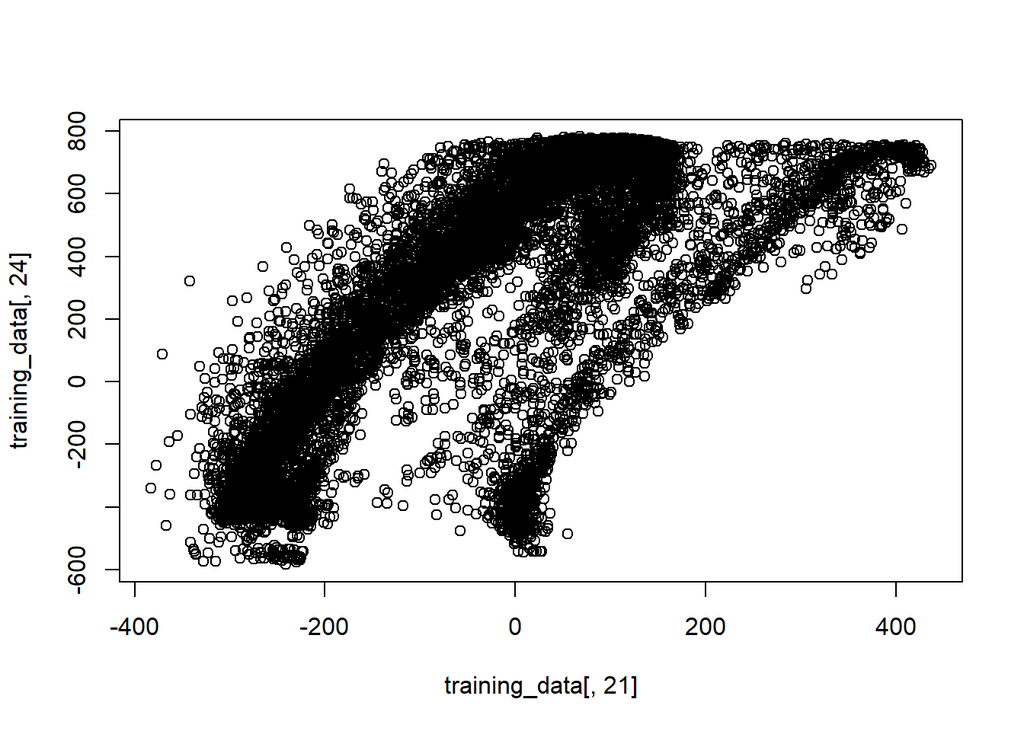

```r
plot(training_data[,21], training_data[,24])
```

```r
preProc<- preProcess (training_data[,-53], method="pca", thresh=0.95)
training_data_preprocess<- predict (preProc, training_data[,-53])
training_data_preprocess$classe=training_data$classe

validation_data_preprocess <- predict (preProc, validation_data[,-53])
validation_data_preprocess$classe=validation_data$classe
```

By validating the data we are able to begin our model building.

```r
 library(randomForest)
fit<-randomForest(classe~., data=training_data)
print(fit)
```

```
##
## Call:
##  randomForest(formula = classe ~ ., data = training_data)
##                Type of random forest: classification
##                      Number of trees: 500
## No. of variables tried at each split: 7
##
##         OOB estimate of  error rate: 0.41%
## Confusion matrix:
##      A    B    C    D    E  class.error
## A 4184    0    0    0    1 0.0002389486
## B   13 2832    3    0    0 0.0056179775
## C    0   13 2551    3    0 0.0062329568
## D    0    0   21 2390    1 0.0091210614
## E    0    0    0    6 2700 0.0022172949
```

```r
confusionMatrix(table(predict(fit, training_data), training_data$classe))
```

```
## Confusion Matrix and Statistics
##
##
##        A    B    C    D    E
##   A 4185    0    0    0    0
##   B    0 2848    0    0    0
##   C    0    0 2567    0    0
##   D    0    0    0 2412    0
##   E    0    0    0    0 2706
##
## Overall Statistics
##
##                Accuracy : 1
##                  95% CI : (0.9997, 1)
##     No Information Rate : 0.2843
##     P-Value [Acc > NIR] : < 2.2e-16
##
##                   Kappa : 1
##  Mcnemar's Test P-Value : NA
##
## Statistics by Class:
##
##                      Class: A Class: B Class: C Class: D Class: E
## Sensitivity            1.0000   1.0000   1.0000   1.0000   1.0000
## Specificity            1.0000   1.0000   1.0000   1.0000   1.0000
## Pos Pred Value         1.0000   1.0000   1.0000   1.0000   1.0000
## Neg Pred Value         1.0000   1.0000   1.0000   1.0000   1.0000
## Prevalence             0.2843   0.1935   0.1744   0.1639   0.1839
## Detection Rate         0.2843   0.1935   0.1744   0.1639   0.1839
## Detection Prevalence   0.2843   0.1935   0.1744   0.1639   0.1839
## Balanced Accuracy      1.0000   1.0000   1.0000   1.0000   1.0000
```

```r
confusionMatrix(table(predict(fit, validation_data), validation_data$classe))
```

```
## Confusion Matrix and Statistics
##
##
##        A    B    C    D    E
##   A 1395    4    0    0    0
##   B    0  943    7    0    0
##   C    0    2  847    8    0
##   D    0    0    1  795    0
##   E    0    0    0    1  901
##
## Overall Statistics
##
##                Accuracy : 0.9953
##                  95% CI : (0.993, 0.997)
##     No Information Rate : 0.2845
##     P-Value [Acc > NIR] : < 2.2e-16
##
##                   Kappa : 0.9941
##  Mcnemar's Test P-Value : NA
##
## Statistics by Class:
##
##                      Class: A Class: B Class: C Class: D Class: E
## Sensitivity            1.0000   0.9937   0.9906   0.9888   1.0000
## Specificity            0.9989   0.9982   0.9975   0.9998   0.9998
## Pos Pred Value         0.9971   0.9926   0.9883   0.9987   0.9989
## Neg Pred Value         1.0000   0.9985   0.9980   0.9978   1.0000
## Prevalence             0.2845   0.1935   0.1743   0.1639   0.1837
## Detection Rate         0.2845   0.1923   0.1727   0.1621   0.1837
## Detection Prevalence   0.2853   0.1937   0.1748   0.1623   0.1839
## Balanced Accuracy      0.9994   0.9960   0.9941   0.9943   0.9999
```

```r
fit_preprocess<-randomForest(classe~., data=training_data_preprocess)
print(fit_preprocess)
```

```
##
## Call:
##  randomForest(formula = classe ~ ., data = training_data_preprocess)
##                Type of random forest: classification
##                      Number of trees: 500
## No. of variables tried at each split: 5
##
##         OOB estimate of  error rate: 2.53%
## Confusion matrix:
##      A    B    C    D    E class.error
## A 4145   12   18    8    2 0.009557945
## B   49 2746   45    3    5 0.035814607
## C    4   32 2488   38    5 0.030775224
## D    4    1   92 2310    5 0.042288557
## E    1   14   22   13 2656 0.018477458
```

```r
confusionMatrix(table(predict(fit_preprocess, training_data_preprocess), training_data_preprocess$classe))
```

```
## Confusion Matrix and Statistics
##
##
##        A    B    C    D    E
##   A 4185    0    0    0    0
##   B    0 2848    0    0    0
##   C    0    0 2567    0    0
##   D    0    0    0 2412    0
##   E    0    0    0    0 2706
##
## Overall Statistics
##
##                Accuracy : 1
##                  95% CI : (0.9997, 1)
##     No Information Rate : 0.2843
##     P-Value [Acc > NIR] : < 2.2e-16
##
##                   Kappa : 1
##  Mcnemar's Test P-Value : NA
##
## Statistics by Class:
##
##                      Class: A Class: B Class: C Class: D Class: E
## Sensitivity            1.0000   1.0000   1.0000   1.0000   1.0000
## Specificity            1.0000   1.0000   1.0000   1.0000   1.0000
## Pos Pred Value         1.0000   1.0000   1.0000   1.0000   1.0000
## Neg Pred Value         1.0000   1.0000   1.0000   1.0000   1.0000
## Prevalence             0.2843   0.1935   0.1744   0.1639   0.1839
## Detection Rate         0.2843   0.1935   0.1744   0.1639   0.1839
## Detection Prevalence   0.2843   0.1935   0.1744   0.1639   0.1839
## Balanced Accuracy      1.0000   1.0000   1.0000   1.0000   1.0000
```

```r
confusionMatrix(table(predict(fit_preprocess, validation_data_preprocess), validation_data_preprocess$classe))
```

```
## Confusion Matrix and Statistics
##
##
##        A    B    C    D    E
##   A 1388   18    1    2    0
##   B    2  916   12    0    8
##   C    4   15  827   32    5
##   D    1    0   13  770    2
##   E    0    0    2    0  886
##
## Overall Statistics
##
##                Accuracy : 0.9761
##                  95% CI : (0.9715, 0.9802)
##     No Information Rate : 0.2845
##     P-Value [Acc > NIR] : < 2.2e-16
##
##                   Kappa : 0.9698
##  Mcnemar's Test P-Value : NA
##
## Statistics by Class:
##
##                      Class: A Class: B Class: C Class: D Class: E
## Sensitivity            0.9950   0.9652   0.9673   0.9577   0.9834
## Specificity            0.9940   0.9944   0.9862   0.9961   0.9995
## Pos Pred Value         0.9851   0.9765   0.9366   0.9796   0.9977
## Neg Pred Value         0.9980   0.9917   0.9930   0.9917   0.9963
## Prevalence             0.2845   0.1935   0.1743   0.1639   0.1837
## Detection Rate         0.2830   0.1868   0.1686   0.1570   0.1807
## Detection Prevalence   0.2873   0.1913   0.1801   0.1603   0.1811
## Balanced Accuracy      0.9945   0.9798   0.9767   0.9769   0.9914
```

Looking at the tables we can see a high level of sensitivity (about 97%) and a relatively small confidence interval.

**Prediction**

```r
test_data <- read.csv("C:/Users/mloun/Documents/pml-testing.csv")
train_lables<- colnames(test_data) %in% colnames(training_data)
test_data_filtered<- test_data[train_lables]
setdiff(names(training_data), names(test_data_filtered))
```

```
## [1] "classe"
```

```r
pred_test<-predict(fit, test_data_filtered)
pred_test
```

```
##  1  2  3  4  5  6  7  8  9 10 11 12 13 14 15 16 17 18 19 20
##  B  A  B  A  A  E  D  B  A  A  B  C  B  A  E  E  A  B  B  B
## Levels: A B C D E
```